# lab_week_3-checkpoint

### Intro to Matplotlib

Matplotlib is a comprehensive library for creating static, animated, and interactive visualizations in Python. It is used along with NumPy to provide an environment that is an effective open source alternative to MatLab. Thus, this may feel very familiar to you if you've ever used MatLab. Please note that Matplotlib is not the only tool for creating data visualization in Python. Other common libraries include [seaborn](https://seaborn.pydata.org/), [plotly](https://plotly.com/), and even [pandas](https://pandas.pydata.org/docs/user_guide/visualization.html) has some built in functions for quick plotting. This lab will mainly focus on Matplotlib, but I highly recommend checking out seaborn as well, since it can make some type of plots much easier to create. The good news is that seaborn is built on top of Matplotlib, so it will be very easy to pick up after going through this lab. However, you're free to use any of the plotting tools mentioned above throughout the course. Just as there were many ways to solve a problem in pandas, there are many ways to visualize our data.

Let's begin by importing matplotlib and learning how to create some beautiful graphs. If for some reason you don't have matplotlib installed, you will first have to go to your terminal (or Anaconda Prompt if on Windows) and enter the following:

```
conda install matplotlib
```

Make sure you've already installed [Anaconda](https://www.anaconda.com/)

```python
import numpy as np
import pandas as pd
import matplotlib.pyplot as plt
```

### Plotting Numpy Arrays

Let's begin by creating some numpy arrays and plotting them. We can create a simple x, y graph using *plt.plot(x, y)*. We can then display this by calling *plt.show()*.

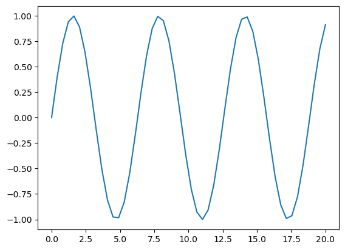

```python
x = np.linspace(0, 20)
y = np.sin(x)
plt.plot(x, y)
plt.show()
```

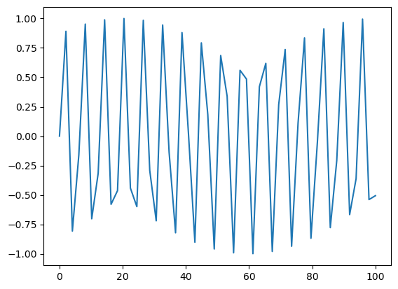

```python
x_2 = np.linspace(0, 100)
y_2 = np.sin(x_2)
plt.plot(x_2, y_2)
plt.show()
```

It's would also be nice to add titles and axis labels to our graphs. We can accomplish this using *plt.title()* and *plt.x/ylabel()*.

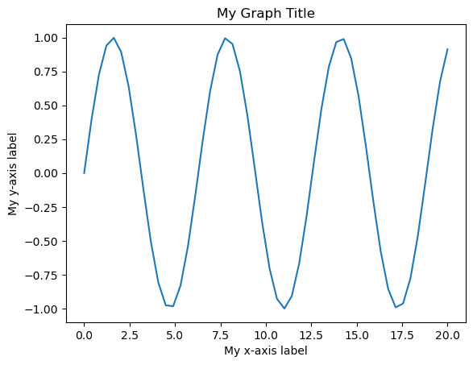

```python
plt.plot(x, y)
plt.title('My Graph Title')
plt.xlabel('My x-axis label')
plt.ylabel('My y-axis label')
plt.show()
```

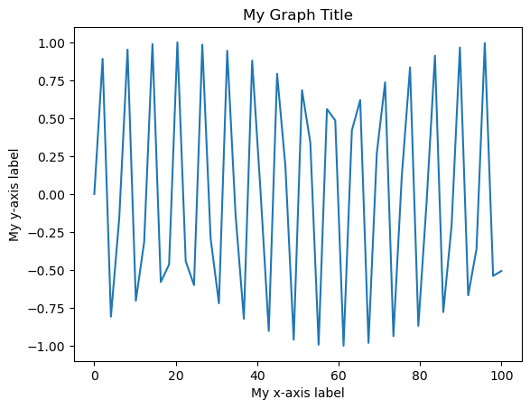

```python
plt.plot(x_2,y_2)
plt.title('My Graph Title')
plt.xlabel('My x-axis label')
plt.ylabel('My y-axis label')
plt.show()
```

*Note: Make sure to add any titles/labels and such before calling plt.show(). Otherwise they will not show up.*

We'll sometimes like to plot more than one function together, which can be done by calling *plt.plot()* a second time in the same cell. However, make sure to add an additional *label* parameter when doing this to give each plot/function a unique label name. That way we can then call *plt.legend()*, which will automatically add a legend for us and let us know which plot is which.

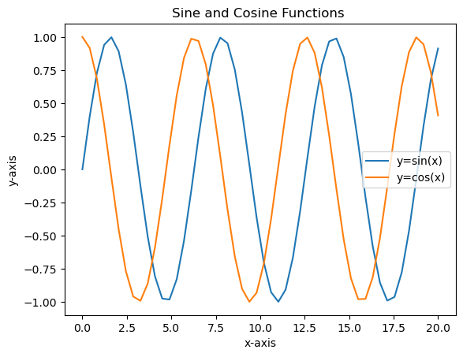

```python
plt.plot(x, np.sin(x), label='y=sin(x)')
plt.plot(x, np.cos(x), label='y=cos(x)')
plt.title('Sine and Cosine Functions ')
plt.xlabel("x-axis")
plt.ylabel("y-axis")
# Assigns a color to each plot along with it's corresponding label name to display in a legend.
plt.legend()
plt.show()
```

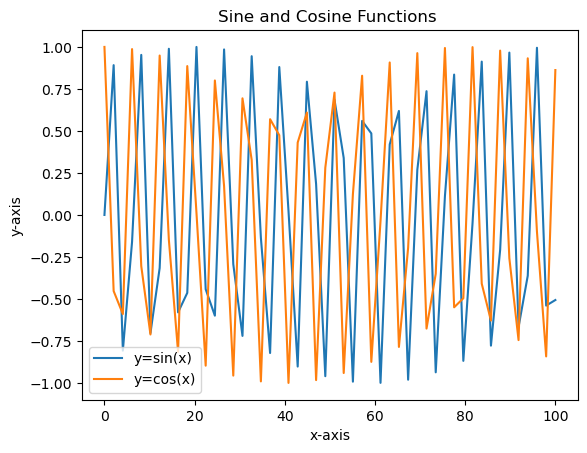

```python
plt.plot(x_2, np.sin(x_2), label='y=sin(x)')
plt.plot(x_2, np.cos(x_2), label='y=cos(x)')
plt.title('Sine and Cosine Functions ')
plt.xlabel("x-axis")
plt.ylabel("y-axis")

plt.legend()
plt.show()
```

### Subplots

What if we instead wanted to plot sin(x) and cos(x) as separate plots, but side by side? This is where *subplots(nrows, ncols)* comes in handy. *subplots(nrows, ncols)* will return to us a figure object and a set of axes. To better understand subplots, think of a figure object as a large canvas where we can place a set of axes on. These set of axes are where we will plot our graphs on. Previously, we only had one single axis in our figure, and we were plotting 1 or many functions on that single axis. However, figures can have many axes, which we'll demonstrate using *subplots(nrows, ncols)*. For example, in the code below we tell *subplots(nrows, ncols)* that we would like a figure object with 1 row and 2 columns (essentially an array with 2 elements, where each element is an axis that we can plot on). Since axes can be thought of as an array holding the figure axes, we can index it to specify what we'd like to plot in each one.

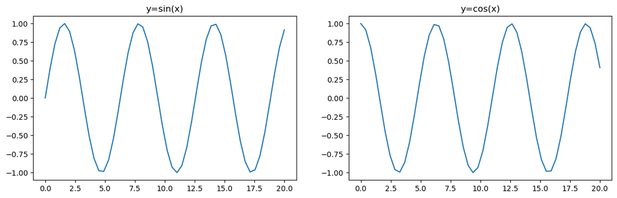

```python
# one figure object with 1x2=2 axes
fig, axes = plt.subplots(nrows=1, ncols=2, figsize=(14, 4))

# plotting sin(x) in axes[0]. left image, or 1st element/axis in the axes array.
axes[0].plot(x, np.sin(x))
# setting the title of axes[0] to be y=sin(x)
axes[0].set_title('y=sin(x)')

# plotting cos(x) in axes[1]. right image, or 2nd element/axis in the axes array.
axes[1].plot(x, np.cos(x))
# setting the title of axes[1] to be y=cos(x)
axes[1].set_title('y=cos(x)')

plt.show()
```

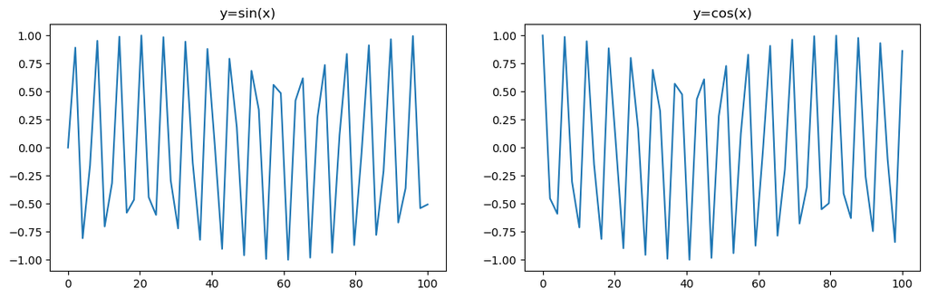

```python
fig, axes = plt.subplots(nrows=1, ncols=2, figsize=(14, 4))

axes[0].plot(x_2, np.sin(x_2))
axes[0].set_title('y=sin(x)')

axes[1].plot(x_2, np.cos(x_2))
axes[1].set_title('y=cos(x)')

plt.show()
```

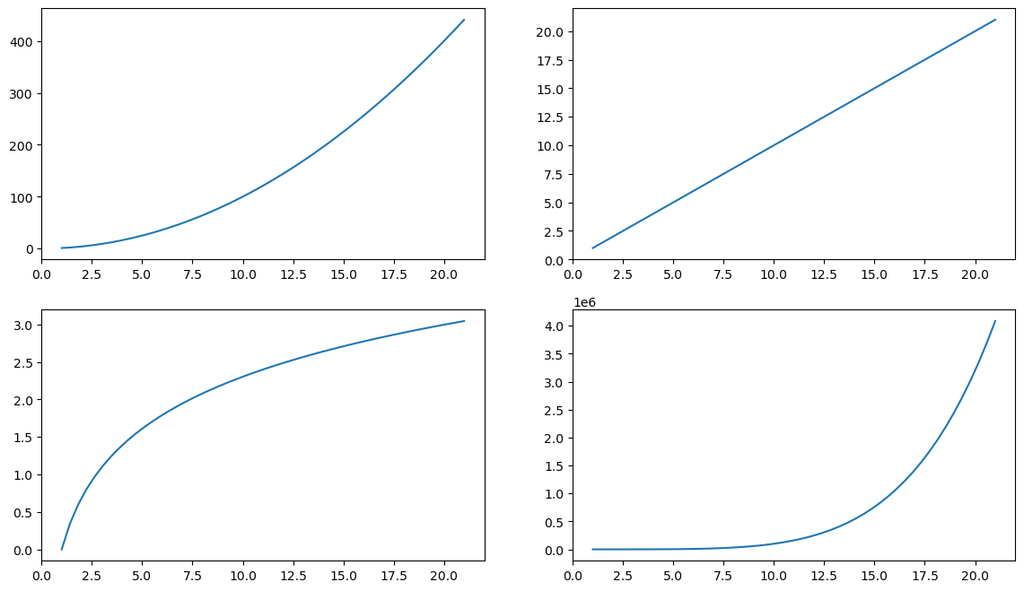

```python
x = np.linspace(1, 21)

fig, axes = plt.subplots(nrows=2, ncols=2, figsize=(14, 8))

axes[0][0].plot(x, x**2)
axes[0][1].plot(x, x)
axes[1][0].plot(x, np.log(x))
axes[1][1].plot(x, x**5)

plt.show()
```

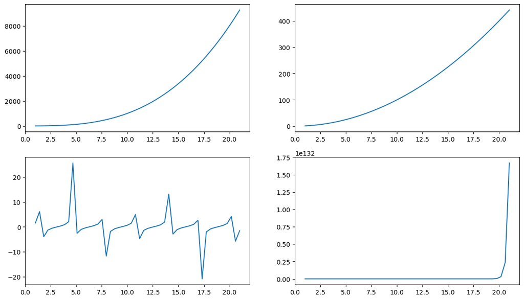

```python
x = np.linspace(1, 21)

fig, axes = plt.subplots(nrows=2, ncols=2, figsize=(14, 8))

axes[0][0].plot(x, x**3)
axes[0][1].plot(x, x*x)
axes[1][0].plot(x, np.tan(x))
axes[1][1].plot(x, x**100)

plt.show()
```

The *plt.plot()* function supports additional arguments that can be used to specify the line color and style. Colors and styles can be specified in a variety of ways. Please check out their website if you ever want a specific color or linestyle, but here are just a few examples:

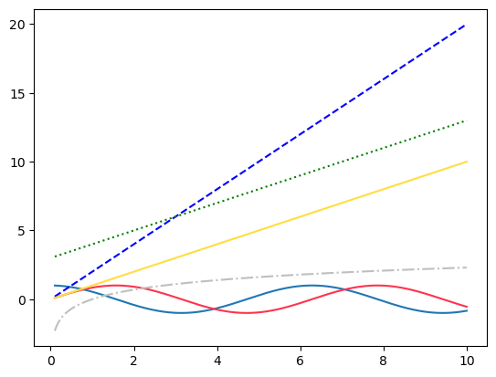

```python
x = np.linspace(0.1,10,1000)
y = 2*x
# set of default color and style
plt.plot(x, np.cos(x))
# RGB tuple, values 0 to 1, solid style
plt.plot(x, np.sin(x), color=(1.0,0.2,0.3),linestyle='-')
# specify color by name, dashed style
plt.plot(x, y, color='blue', linestyle='--')
# short color code (rgbcmyk), dotted style
plt.plot(x, x+3, color='g',linestyle=':')
# Grayscale between 0 and 1, dashdot style
plt.plot(x, np.log(x), color='0.75',linestyle='-.')
# Hex code (RRGGBB from 00 to FF), dashed style
plt.plot(x, x, color='#FFDD44',linestyle='-')
plt.show()
```

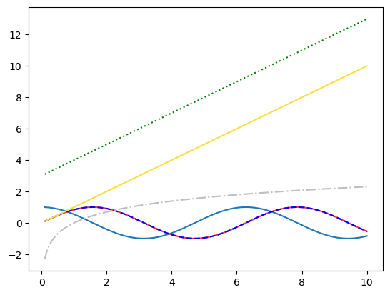

```python
x = np.linspace(0.1, 10, 1000)
y = np.sin(x)

plt.plot(x, np.cos(x))

plt.plot(x, np.sin(x), color=(1.0, 0.2, 0.3), linestyle='-')

plt.plot(x, y, color='blue', linestyle='--')

plt.plot(x, x+3, color='g', linestyle=':')

plt.plot(x, np.log(x), color='0.75', linestyle='-.')

plt.plot(x, x, color='#FFDD44', linestyle='-')

plt.show()
```